# Linear Regression and its cousin

Author

Guibril Ramde

## **Part: 6.2.**

1. **Start R and use these commands to load the data:**

```r
library(tidyverse)
library(fpp3)
library(AppliedPredictiveModeling)
library(caret)
data(permeability)
head(permeability, 15)
```

```
   permeability
1        12.520
2         1.120
3        19.405
4         1.730
5         1.680
6         0.510
7        25.365
8         0.550
9        39.455
10        4.910
11        0.550
12        1.570
13        0.060
14        5.560
15        3.850
```

```r
#head(fingerprints, 5)

dim(permeability)
```

```
[1] 165   1
```

```r
dim(fingerprints)
```

```
[1]  165 1107
```

```r
str(permeability)
```

```
 num [1:165, 1] 12.52 1.12 19.41 1.73 1.68 ...
 - attr(*, "dimnames")=List of 2
  ..$ : chr [1:165] "1" "2" "3" "4" ...
  ..$ : chr "permeability"
```

```r
str(fingerprints)
```

```
 num [1:165, 1:1107] 0 0 0 0 0 0 0 0 0 0 ...
 - attr(*, "dimnames")=List of 2
  ..$ : chr [1:165] "1" "2" "3" "4" ...
  ..$ : chr [1:1107] "X1" "X2" "X3" "X4" ...
```

## **Exploratory Data Analysis**

```r
# missing values
sum(is.na(permeability))
```

```
[1] 0
```

```r
sum(is.na(fingerprints))
```

```
[1] 0
```

```r
summary(permeability)
```

```
  permeability
 Min.   : 0.06
 1st Qu.: 1.55
 Median : 4.91
 Mean   :12.24
 3rd Qu.:15.47
 Max.   :55.60
```

```r
# Count of presence of each molecular substructure
fingerprint_counts <- colSums(fingerprints, dims = 1)
# summary of frequencies
summary(fingerprint_counts)
```

```
   Min. 1st Qu.  Median    Mean 3rd Qu.    Max.
   0.00    1.00    4.00   25.54   30.00  165.00
```

```r
# predictor that are not present 0
sum(fingerprint_counts == 0)
```

```
[1] 20
```

```r
# number of occurance < 5
sum(fingerprint_counts < 5)
```

```
[1] 564
```

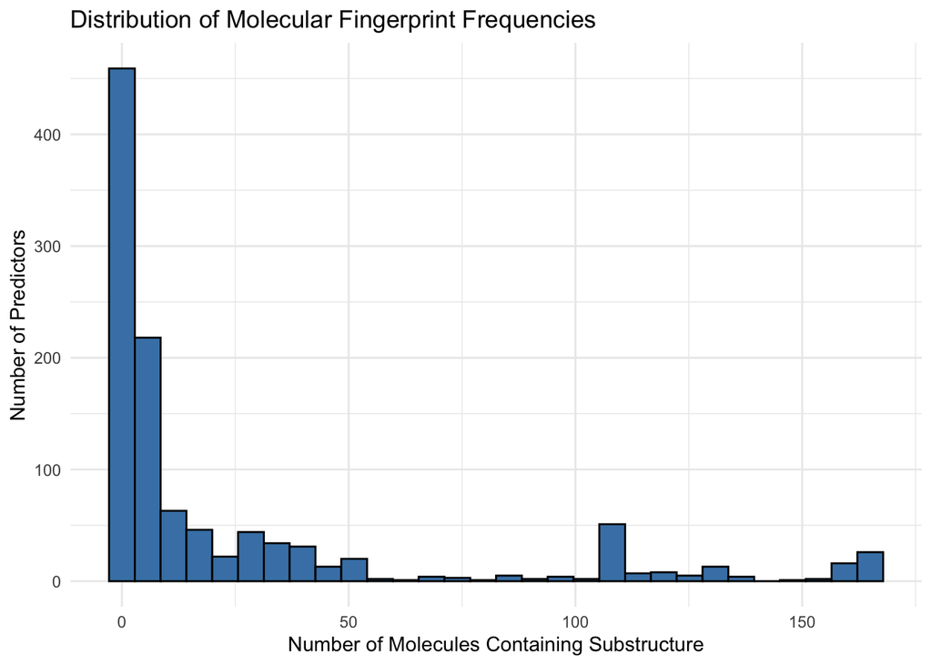

```r
# visualize the fingerprints data
fingerprint_df <- tibble(
  Frequency = as.numeric(fingerprint_counts)
)

ggplot(fingerprint_df, aes(x = Frequency)) +
  geom_histogram(
    bins = 30,
    fill = "steelblue",
    color = "black"
  ) +
  labs(
    title = "Distribution of Molecular Fingerprint Frequencies",
    x = "Number of Molecules Containing Substructure",
    y = "Number of Predictors"
  ) +
  theme_minimal()
```

## **Interpretation**

If most predictors have frequencies close to zero, it means many molecular substructures occur in only a small number of molecules. These sparse predictors may provide limited information for regression modeling.

**b. The fingerprint predictors indicate the presence or absence of substructures of a molecule and are often sparse meaning that relatively few of the molecules contain each substructure. Filter out the predictors that have low frequencies using the `nearZeroVar` function from the caret package. How many predictors are left for modeling?**

```r
# Identify near-zero variance predictor
nzv <- nearZeroVar(fingerprints)

# number of predictor before filtering
ncol(fingerprints)
```

```
[1] 1107
```

```r
length(nzv)
```

```
[1] 719
```

```r
# remove near - zero - variance predictors
fingerprints_filtered <- fingerprints[, -nzv, drop = FALSE]

# number of predictor remaining
ncol(fingerprints_filtered)
```

```
[1] 388
```

```r
nzv_details <- nearZeroVar(fingerprints, saveMetrics = TRUE)
head(nzv_details, 10)
```

```
    freqRatio percentUnique zeroVar   nzv
X1   3.342105     1.2121212   FALSE FALSE
X2   3.459459     1.2121212   FALSE FALSE
X3   3.714286     1.2121212   FALSE FALSE
X4   3.714286     1.2121212   FALSE FALSE
X5   3.714286     1.2121212   FALSE FALSE
X6   1.229730     1.2121212   FALSE FALSE
X7   0.000000     0.6060606    TRUE  TRUE
X8   0.000000     0.6060606    TRUE  TRUE
X9  54.000000     1.2121212   FALSE  TRUE
X10 40.250000     1.2121212   FALSE  TRUE
```

```r
table(nzv_details$nzv)
```

```
FALSE  TRUE
  388   719
```

## Interpretation:

The fingerprint dataset initially contained `1107` predictors. I applied the `nearZeroVar()` function from the `caret` package to identify predictors with little or no variation. After removing `719` predictors, `388` predictors remained for modeling. This preprocessing step reduces the number of uninformative predictors and may improve computational efficiency.

## **c. Split the data into a training and a test set, pre-process the data, and tune a PLS model. How many latent variables are optimal and what is the corresponding resampled estimate of R2?**

```r
# Combine predictors and target
model_data <- as.data.frame(fingerprints) |>
  mutate(Permeability = as.numeric(permeability))

# Verify dimensions
dim(model_data)
```

```
[1]  165 1108
```

```r
# Check target
summary(model_data$Permeability)
```

```
   Min. 1st Qu.  Median    Mean 3rd Qu.    Max.
   0.06    1.55    4.91   12.24   15.47   55.60
```

```r
# Check missing values
sum(is.na(model_data$Permeability))
```

```
[1] 0
```

```r
set.seed(42)

train_index <- createDataPartition(
  y = model_data$Permeability,
  p = 0.80,
  list = FALSE
)

train_data <- model_data[train_index, ]
test_data <- model_data[-train_index, ]

dim(train_data)
```

```
[1]  133 1108
```

```r
dim(test_data)
```

```
[1]   32 1108
```

```r
# Predictors
x_train <- train_data |>
  select(-Permeability)

x_test <- test_data |>
  select(-Permeability)

# Convert target to numeric vectors
y_train <- as.numeric(train_data$Permeability)
y_test <- as.numeric(test_data$Permeability)

# Verify
class(y_train)
```

```
[1] "numeric"
```

```r
is.numeric(y_train)
```

```
[1] TRUE
```

```r
length(y_train)
```

```
[1] 133
```

```r
summary(y_train)
```

```
   Min. 1st Qu.  Median    Mean 3rd Qu.    Max.
   0.06    1.55    4.91   12.18   15.47   55.60
```

```r
# Check dimensions
dim(x_train)
```

```
[1]  133 1107
```

```r
dim(x_test)
```

```
[1]   32 1107
```

```r
length(y_train)
```

```
[1] 133
```

```r
length(y_test)
```

```
[1] 32
```

```r
# Identify near-zero variance predictors
nzv_train <- nearZeroVar(x_train)

# Filter training and testing predictors
keep_cols <- setdiff(seq_len(ncol(x_train)), nzv_train)

x_train_filtered <- x_train[, keep_cols, drop = FALSE]
x_test_filtered <- x_test[, keep_cols, drop = FALSE]

# Verify dimensions
dim(x_train_filtered)
```

```
[1] 133 393
```

```r
dim(x_test_filtered)
```

```
[1]  32 393
```

```r
nrow(fingerprints)
```

```
[1] 165
```

```r
length(permeability)
```

```
[1] 165
```

```r
ncol(x_train_filtered)
```

```
[1] 393
```

```r
#install.packages("pls")
library(caret)
library(pls)
set.seed(42)

# Configure repeated cross-validation
train_control <- trainControl(
  method = "repeatedcv",
  number = 10,
  repeats = 3
)

# Train the PLS regression model
pls_model <- train(
  x = x_train_filtered,
  y = y_train,
  method = "pls",
  preProcess = c("center", "scale"),
  tuneGrid = expand.grid(ncomp = 1:30),
  trControl = train_control,
  metric = "Rsquared"
)

# Display model summary
print(pls_model)
```

```
Partial Least Squares

133 samples
393 predictors

Pre-processing: centered (393), scaled (393)
Resampling: Cross-Validated (10 fold, repeated 3 times)
Summary of sample sizes: 119, 121, 120, 120, 118, 119, ...
Resampling results across tuning parameters:

  ncomp  RMSE      Rsquared   MAE
   1     13.07548  0.3359875   9.966304
   2     12.25093  0.4317432   8.787737
   3     12.31039  0.4299298   9.395322
   4     12.14453  0.4438789   9.211818
```

[output cut: 29 more lines]

```r
# Optimal number of latent variables
pls_model$bestTune
```

```
  ncomp
7     7
```

```r
# Corresponding resampled R-squared
best_result <- pls_model$results |>
  filter(ncomp == pls_model$bestTune$ncomp)

best_result |>
  select(ncomp, RMSE, Rsquared)
```

```
  ncomp     RMSE  Rsquared
1     7 11.00772 0.5466184
```

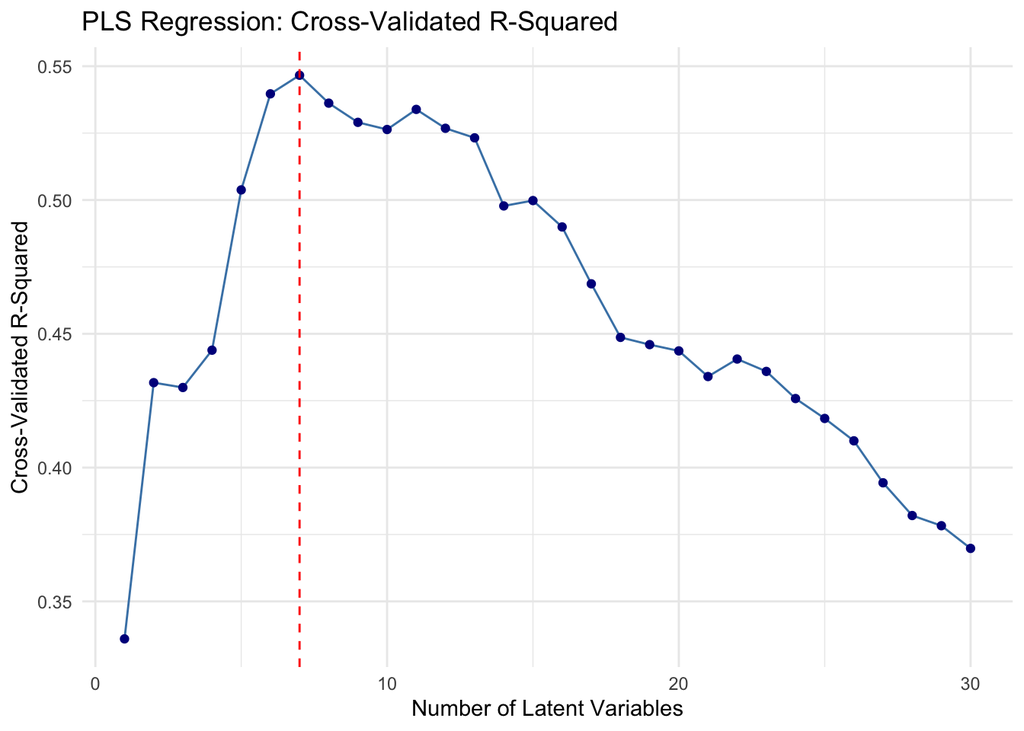

```r
ggplot(pls_model$results, aes(x = ncomp, y = Rsquared)) +
  geom_line(color = "steelblue") +
  geom_point(color = "darkblue") +
  geom_vline(
    xintercept = pls_model$bestTune$ncomp,
    linetype = "dashed",
    color = "red"
  ) +
  labs(
    title = "PLS Regression: Cross-Validated R-Squared",
    x = "Number of Latent Variables",
    y = "Cross-Validated R-Squared"
  ) +
  theme_minimal()
```

### Interpretation: Training and Test Data Preparation

The data set contains 165 molecular observations and 1,107 fingerprint predictors. The data were divided into a training set containing 133 observations (approximately 80%) and a testing set containing 32 observations (approximately 20%).

Near-zero-variance filtering was applied to the training predictors to remove variables with little or no variation. Of the original 1,107 predictors, 714 were removed, leaving 393 predictors for model development. The same predictor columns were retained in the testing data set to ensure consistency.

The response variable is molecular permeability, which is continuous. Therefore, Partial Least Squares regression was selected to predict permeability from the molecular fingerprint predictors.

4. **Predict the response for the test set. What is the test set estimate of R2?**

```r
# Predict molecular permeability for the test set
pls_predictions <- predict(
  pls_model,
  newdata = x_test_filtered
)

# View predictions
head(pls_predictions)
```

```
[1] 20.527796  9.447243 28.548741  6.953834 18.627001  8.834673
```

```r
# Calculate RMSE, R-squared, and MAE
pls_test_results <- postResample(
  pred = pls_predictions,
  obs = y_test
)

pls_test_results
```

```
      RMSE   Rsquared        MAE
13.0723693  0.3560746 10.1451370
```

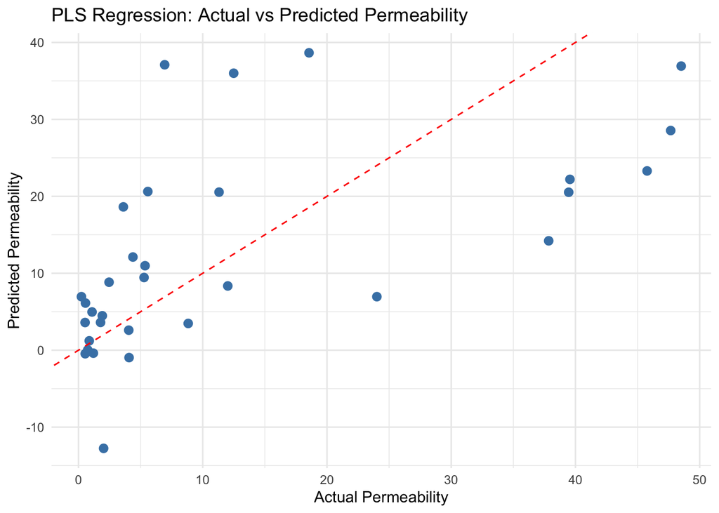

```r
# Visualize
pls_test_df <- tibble(
  Actual = y_test,
  Predicted = as.numeric(pls_predictions)
)

ggplot(pls_test_df, aes(x = Actual, y = Predicted)) +
  geom_point(color = "steelblue", size = 2.5) +
  geom_abline(
    slope = 1,
    intercept = 0,
    linetype = "dashed",
    color = "red"
  ) +
  labs(
    title = "PLS Regression: Actual vs Predicted Permeability",
    x = "Actual Permeability",
    y = "Predicted Permeability"
  ) +
  theme_minimal()
```

4. **Interpretation:** Actual vs. Predicted Permeability

[output not shown]

5. **Try building other models discussed in this chapter. Do any have better predictive performance?**

```r
#install.packages("glmnet")
library(glmnet)
set.seed(42)

ridge_model <- train(
  x = x_train_filtered,
  y = y_train,
  method = "glmnet",
  preProcess = c("center", "scale"),
  tuneGrid = expand.grid(
    alpha = 0,
    lambda = 10^seq(-4, 2, length.out = 50)
  ),
  trControl = train_control,
  metric = "Rsquared"
)

ridge_model$bestTune
```

```
   alpha  lambda
49     0 75.4312
```

```r
## Lasso Regression
set.seed(42)

lasso_model <- train(
  x = x_train_filtered,
  y = y_train,
  method = "glmnet",
  preProcess = c("center", "scale"),
  tuneGrid = expand.grid(
    alpha = 1,
    lambda = 10^seq(-4, 2, length.out = 50)
  ),
  trControl = train_control,
  metric = "Rsquared"
)
lasso_model$bestTune
```

```
   alpha   lambda
30     1 0.355648
```

```r
# Evaluate both models
# Ridge predictions
ridge_predictions <- predict(
  ridge_model,
  newdata = x_test_filtered
)

# Lasso predictions
lasso_predictions <- predict(
  lasso_model,
  newdata = x_test_filtered
)

# Test performance
ridge_results <- postResample(
  ridge_predictions,
  y_test
)

lasso_results <- postResample(
  lasso_predictions,
  y_test
)
```

```r
# Compare all three models
model_comparison <- tibble(
  Model = c("PLS", "Ridge", "Lasso"),
  RMSE = c(
    pls_test_results["RMSE"],
    ridge_results["RMSE"],
    lasso_results["RMSE"]
  ),
  Rsquared = c(
    pls_test_results["Rsquared"],
    ridge_results["Rsquared"],
    lasso_results["Rsquared"]
  ),
  MAE = c(
    pls_test_results["MAE"],
    ridge_results["MAE"],
    lasso_results["MAE"]
  )
)

model_comparison
```

```
# A tibble: 3 × 4
  Model  RMSE Rsquared   MAE
  <chr> <dbl>    <dbl> <dbl>
1 PLS    13.1    0.356 10.1
2 Ridge  10.7    0.583  8.14
3 Lasso  13.1    0.324 10.4
```

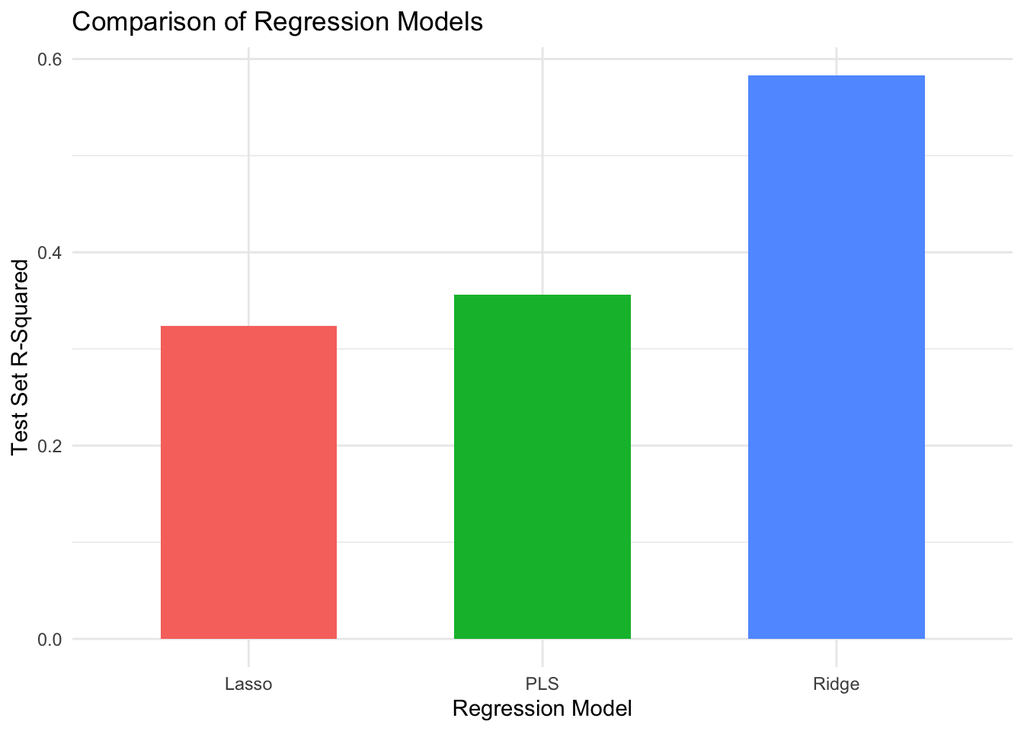

```r
ggplot(model_comparison, aes(x = Model, y = Rsquared, fill = Model)) +
  geom_col(width = 0.6) +
  labs(
    title = "Comparison of Regression Models",
    x = "Regression Model",
    y = "Test Set R-Squared"
  ) +
  theme_minimal() +
  theme(legend.position = "none")
```

### Interpretation: Comparison of Regression Models

Three regression models were evaluated to predict molecular permeability: Partial Least Squares (PLS), Ridge Regression, and Lasso Regression. Their predictive performances were compared using R-squared (R²), Root Mean Squared Error (RMSE), and Mean Absolute Error (MAE).

Ridge Regression achieved the best predictive performance, with an R² of 0.5832, RMSE of 10.6637, and MAE of 8.1449. PLS Regression achieved an R² of 0.3561, while Lasso Regression had the lowest R² of 0.3239.

These results indicate that Ridge Regression performs better than the other two models on the testing data set. Ridge Regression may be more effective because it reduces the influence of individual predictors through regularization while retaining information from all predictors.

Therefore, Ridge Regression is the preferred model among the three approaches evaluated. However, further validation would be necessary to confirm its reliability on new molecular observations.

**f. Would you recommend any of your models to replace the permeability laboratory experiment?**

### Interpretation: Recommendation

Based on the results, I would not recommend replacing the laboratory permeability experiment entirely with any of the regression models.

Although Ridge Regression achieved the highest R² of 0.5832 and the lowest RMSE of 10.6637, its predictions still contain substantial errors. This suggests that the model does not fully capture the relationship between molecular fingerprints and permeability.

Additionally, the data set contains only 165 molecular observations, with 32 observations used for testing. This relatively small testing data set limits our confidence in the model’s ability to generalize to new molecules.

However, Ridge Regression could be useful as a preliminary screening tool to estimate molecular permeability and identify molecules that require further laboratory testing. Additional observations, external validation, and further model improvement would be necessary before considering it a replacement for laboratory experiments.

# **Part 6.3**

a. **Start R and use these commands to load the data: > library(AppliedPredictiveModeling) > data(chemicalManufacturingProcess) The matrix processPredictors contains the 57 predictors (12 describing the input biological material and 45 describing the process predictors) for the 176 manufacturing runs. yield contains the percent yield for each run.**

**Exploratory Data Analysis**

```r
data(ChemicalManufacturingProcess)
head(ChemicalManufacturingProcess)
```

```
  Yield BiologicalMaterial01 BiologicalMaterial02 BiologicalMaterial03
1 38.00                 6.25                49.58                56.97
2 42.44                 8.01                60.97                67.48
3 42.03                 8.01                60.97                67.48
4 41.42                 8.01                60.97                67.48
5 42.49                 7.47                63.33                72.25
6 43.57                 6.12                58.36                65.31
  BiologicalMaterial04 BiologicalMaterial05 BiologicalMaterial06
1                12.74                19.51                43.73
2                14.65                19.36                53.14
3                14.65                19.36                53.14
4                14.65                19.36                53.14
5                14.02                17.91                54.66
6                15.17                21.79                51.23
  BiologicalMaterial07 BiologicalMaterial08 BiologicalMaterial09
```

[output cut: 118 more lines]

```r
nrow(ChemicalManufacturingProcess)
```

```
[1] 176
```

```r
dim(ChemicalManufacturingProcess)
```

```
[1] 176  58
```

```r
sum(is.na(ChemicalManufacturingProcess))
```

```
[1] 106
```

```r
str(ChemicalManufacturingProcess)
```

```
'data.frame':   176 obs. of  58 variables:
 $ Yield                 : num  38 42.4 42 41.4 42.5 ...
 $ BiologicalMaterial01  : num  6.25 8.01 8.01 8.01 7.47 6.12 7.48 6.94 6.94 6.94 ...
 $ BiologicalMaterial02  : num  49.6 61 61 61 63.3 ...
 $ BiologicalMaterial03  : num  57 67.5 67.5 67.5 72.2 ...
 $ BiologicalMaterial04  : num  12.7 14.7 14.7 14.7 14 ...
 $ BiologicalMaterial05  : num  19.5 19.4 19.4 19.4 17.9 ...
 $ BiologicalMaterial06  : num  43.7 53.1 53.1 53.1 54.7 ...
 $ BiologicalMaterial07  : num  100 100 100 100 100 100 100 100 100 100 ...
 $ BiologicalMaterial08  : num  16.7 19 19 19 18.2 ...
 $ BiologicalMaterial09  : num  11.4 12.6 12.6 12.6 12.8 ...
 $ BiologicalMaterial10  : num  3.46 3.46 3.46 3.46 3.05 3.78 3.04 3.85 3.85 3.85 ...
 $ BiologicalMaterial11  : num  138 154 154 154 148 ...
 $ BiologicalMaterial12  : num  18.8 21.1 21.1 21.1 21.1 ...
 $ ManufacturingProcess01: num  NA 0 0 0 10.7 12 11.5 12 12 12 ...
```

[output cut: 44 more lines]

```r
names(ChemicalManufacturingProcess)
```

```
 [1] "Yield"                  "BiologicalMaterial01"   "BiologicalMaterial02"
 [4] "BiologicalMaterial03"   "BiologicalMaterial04"   "BiologicalMaterial05"
 [7] "BiologicalMaterial06"   "BiologicalMaterial07"   "BiologicalMaterial08"
[10] "BiologicalMaterial09"   "BiologicalMaterial10"   "BiologicalMaterial11"
[13] "BiologicalMaterial12"   "ManufacturingProcess01" "ManufacturingProcess02"
[16] "ManufacturingProcess03" "ManufacturingProcess04" "ManufacturingProcess05"
[19] "ManufacturingProcess06" "ManufacturingProcess07" "ManufacturingProcess08"
[22] "ManufacturingProcess09" "ManufacturingProcess10" "ManufacturingProcess11"
[25] "ManufacturingProcess12" "ManufacturingProcess13" "ManufacturingProcess14"
[28] "ManufacturingProcess15" "ManufacturingProcess16" "ManufacturingProcess17"
[31] "ManufacturingProcess18" "ManufacturingProcess19" "ManufacturingProcess20"
[34] "ManufacturingProcess21" "ManufacturingProcess22" "ManufacturingProcess23"
[37] "ManufacturingProcess24" "ManufacturingProcess25" "ManufacturingProcess26"
[40] "ManufacturingProcess27" "ManufacturingProcess28" "ManufacturingProcess29"
[43] "ManufacturingProcess30" "ManufacturingProcess31" "ManufacturingProcess32"
[46] "ManufacturingProcess33" "ManufacturingProcess34" "ManufacturingProcess35"
[49] "ManufacturingProcess36" "ManufacturingProcess37" "ManufacturingProcess38"
[52] "ManufacturingProcess39" "ManufacturingProcess40" "ManufacturingProcess41"
[55] "ManufacturingProcess42" "ManufacturingProcess43" "ManufacturingProcess44"
[58] "ManufacturingProcess45"
```

```r
summary(ChemicalManufacturingProcess)
```

```
     Yield       BiologicalMaterial01 BiologicalMaterial02 BiologicalMaterial03
 Min.   :35.25   Min.   :4.580        Min.   :46.87        Min.   :56.97
 1st Qu.:38.75   1st Qu.:5.978        1st Qu.:52.68        1st Qu.:64.98
 Median :39.97   Median :6.305        Median :55.09        Median :67.22
 Mean   :40.18   Mean   :6.411        Mean   :55.69        Mean   :67.70
 3rd Qu.:41.48   3rd Qu.:6.870        3rd Qu.:58.74        3rd Qu.:70.43
 Max.   :46.34   Max.   :8.810        Max.   :64.75        Max.   :78.25

 BiologicalMaterial04 BiologicalMaterial05 BiologicalMaterial06
 Min.   : 9.38        Min.   :13.24        Min.   :40.60
 1st Qu.:11.24        1st Qu.:17.23        1st Qu.:46.05
 Median :12.10        Median :18.49        Median :48.46
 Mean   :12.35        Mean   :18.60        Mean   :48.91
 3rd Qu.:13.22        3rd Qu.:19.90        3rd Qu.:51.34
 Max.   :23.09        Max.   :24.85        Max.   :59.38

 BiologicalMaterial07 BiologicalMaterial08 BiologicalMaterial09
 Min.   :100.0        Min.   :15.88        Min.   :11.44
 1st Qu.:100.0        1st Qu.:17.06        1st Qu.:12.60
 Median :100.0        Median :17.51        Median :12.84
 Mean   :100.0        Mean   :17.49        Mean   :12.85
 3rd Qu.:100.0        3rd Qu.:17.88        3rd Qu.:13.13
 Max.   :100.8        Max.   :19.14        Max.   :14.08

 BiologicalMaterial10 BiologicalMaterial11 BiologicalMaterial12
 Min.   :1.770        Min.   :135.8        Min.   :18.35
 1st Qu.:2.460        1st Qu.:143.8        1st Qu.:19.73
 Median :2.710        Median :146.1        Median :20.12
 Mean   :2.801        Mean   :147.0        Mean   :20.20
 3rd Qu.:2.990        3rd Qu.:149.6        3rd Qu.:20.75
 Max.   :6.870        Max.   :158.7        Max.   :22.21

 ManufacturingProcess01 ManufacturingProcess02 ManufacturingProcess03
 Min.   : 0.00          Min.   : 0.00          Min.   :1.47
 1st Qu.:10.80          1st Qu.:19.30          1st Qu.:1.53
 Median :11.40          Median :21.00          Median :1.54
 Mean   :11.21          Mean   :16.68          Mean   :1.54
 3rd Qu.:12.15          3rd Qu.:21.50          3rd Qu.:1.55
 Max.   :14.10          Max.   :22.50          Max.   :1.60
 NA's   :1              NA's   :3              NA's   :15
```

[output cut: 96 more lines]

```
 ManufacturingProcess40 ManufacturingProcess41 ManufacturingProcess42
 Min.   :0.00000        Min.   :0.00000        Min.   : 0.00
 1st Qu.:0.00000        1st Qu.:0.00000        1st Qu.:11.40
 Median :0.00000        Median :0.00000        Median :11.60
 Mean   :0.01771        Mean   :0.02371        Mean   :11.21
 3rd Qu.:0.00000        3rd Qu.:0.00000        3rd Qu.:11.70
 Max.   :0.10000        Max.   :0.20000        Max.   :12.10
 NA's   :1              NA's   :1
 ManufacturingProcess43 ManufacturingProcess44 ManufacturingProcess45
 Min.   : 0.0000        Min.   :0.000          Min.   :0.000
 1st Qu.: 0.6000        1st Qu.:1.800          1st Qu.:2.100
 Median : 0.8000        Median :1.900          Median :2.200
 Mean   : 0.9119        Mean   :1.805          Mean   :2.138
 3rd Qu.: 1.0250        3rd Qu.:1.900          3rd Qu.:2.300
 Max.   :11.0000        Max.   :2.100          Max.   :2.600
```

**b. A small percentage of cells in the predictor set contain missing values. Use an imputation function to fill in these missing values (e.g., see Sect. 3.8).**

```r
## Separate predictors and response
process_predictors <- ChemicalManufacturingProcess |>
  select(-Yield)

yield <- as.numeric(ChemicalManufacturingProcess$Yield)

# Missing values in predictors
sum(is.na(process_predictors))
```

```
[1] 106
```

```r
# Number of missing values per predictor
missing_counts <- colSums(is.na(process_predictors))

# Display only predictors with missing values
missing_counts[missing_counts > 0]
```

```
ManufacturingProcess01 ManufacturingProcess02 ManufacturingProcess03
                     1                      3                     15
ManufacturingProcess04 ManufacturingProcess05 ManufacturingProcess06
                     1                      1                      2
ManufacturingProcess07 ManufacturingProcess08 ManufacturingProcess10
                     1                      1                      9
ManufacturingProcess11 ManufacturingProcess12 ManufacturingProcess14
                    10                      1                      1
ManufacturingProcess22 ManufacturingProcess23 ManufacturingProcess24
                     1                      1                      1
ManufacturingProcess25 ManufacturingProcess26 ManufacturingProcess27
                     5                      5                      5
ManufacturingProcess28 ManufacturingProcess29 ManufacturingProcess30
                     5                      5                      5
ManufacturingProcess31 ManufacturingProcess33 ManufacturingProcess34
                     5                      5                      5
ManufacturingProcess35 ManufacturingProcess36 ManufacturingProcess40
                     5                      5                      1
ManufacturingProcess41
                     1
```

**c. Split the data into a training and a test set, pre-process the data, and tune a model of your choice from this chapter. What is the optimal value of the performance metric?**

```r
library(caret)
library(glmnet)
library(tidyverse)

set.seed(42)

train_index <- createDataPartition(
  y = yield,
  p = 0.80,
  list = FALSE
)

x_train <- process_predictors[train_index, ]
x_test <- process_predictors[-train_index, ]

y_train <- yield[train_index]
y_test <- yield[-train_index]

dim(x_train)
```

```
[1] 144  57
```

```r
dim(x_test)
```

```
[1] 32 57
```

```r
length(y_train)
```

```
[1] 144
```

```r
length(y_test)
```

```
[1] 32
```

```r
# Define preprocessing using training data only
preprocess_model <- preProcess(
  x_train,
  method = c("medianImpute", "nzv", "center", "scale")
)

# Apply the same preprocessing to both datasets
x_train_processed <- predict(preprocess_model, x_train)
x_test_processed <- predict(preprocess_model, x_test)

# Verify missing values
sum(is.na(x_train_processed))
```

```
[1] 0
```

```r
sum(is.na(x_test_processed))
```

```
[1] 0
```

```r
# Check dimensions
dim(x_train_processed)
```

```
[1] 144  56
```

```r
dim(x_test_processed)
```

```
[1] 32 56
```

```r
set.seed(42)

train_control <- trainControl(
  method = "repeatedcv",
  number = 10,
  repeats = 3
)

ridge_model <- caret::train(
  x = x_train,
  y = y_train,
  method = "glmnet",
  preProcess = c("medianImpute", "nzv", "center", "scale"),
  tuneGrid = expand.grid(
    alpha = 0,
    lambda = 10^seq(-4, 2, length.out = 50)
  ),
  trControl = train_control,
  metric = "RMSE"
)

print(ridge_model)
```

```
glmnet

144 samples
 57 predictor

Pre-processing: median imputation (56), centered (56), scaled (56), remove (1)
Resampling: Cross-Validated (10 fold, repeated 3 times)
Summary of sample sizes: 129, 129, 130, 129, 130, 130, ...
Resampling results across tuning parameters:

  lambda        RMSE      Rsquared   MAE
  1.000000e-04  2.158858  0.5117213  1.298061
  1.325711e-04  2.158858  0.5117213  1.298061
  1.757511e-04  2.158858  0.5117213  1.298061
  2.329952e-04  2.158858  0.5117213  1.298061
  3.088844e-04  2.158858  0.5117213  1.298061
  4.094915e-04  2.158858  0.5117213  1.298061
  5.428675e-04  2.158858  0.5117213  1.298061
  7.196857e-04  2.158858  0.5117213  1.298061
  9.540955e-04  2.158858  0.5117213  1.298061
  1.264855e-03  2.158858  0.5117213  1.298061
  1.676833e-03  2.158858  0.5117213  1.298061
  2.222996e-03  2.158858  0.5117213  1.298061
  2.947052e-03  2.158858  0.5117213  1.298061
  3.906940e-03  2.158858  0.5117213  1.298061
  5.179475e-03  2.158858  0.5117213  1.298061
  6.866488e-03  2.158858  0.5117213  1.298061
  9.102982e-03  2.158858  0.5117213  1.298061
  1.206793e-02  2.158858  0.5117213  1.298061
  1.599859e-02  2.158858  0.5117213  1.298061
  2.120951e-02  2.158858  0.5117213  1.298061
  2.811769e-02  2.158858  0.5117213  1.298061
  3.727594e-02  2.158858  0.5117213  1.298061
  4.941713e-02  2.158858  0.5117213  1.298061
  6.551286e-02  2.158858  0.5117213  1.298061
  8.685114e-02  2.158858  0.5117213  1.298061
  1.151395e-01  2.144871  0.5133782  1.292843
  1.526418e-01  2.083028  0.5187541  1.271108
  2.023590e-01  2.011444  0.5234753  1.247004
  2.682696e-01  1.931524  0.5270870  1.219348
```

[output cut: 10 more lines]

```
  5.963623e+00  1.476015  0.4882065  1.178372
  7.906043e+00  1.500852  0.4716366  1.210973
  1.048113e+01  1.522627  0.4576499  1.242323
  1.389495e+01  1.542775  0.4457845  1.270966
  1.842070e+01  1.563173  0.4358073  1.297224
  2.442053e+01  1.585196  0.4275218  1.320770
  3.237458e+01  1.609141  0.4207662  1.342331
  4.291934e+01  1.634258  0.4153639  1.360636
  5.689866e+01  1.659216  0.4111335  1.376917
  7.543120e+01  1.682681  0.4078685  1.392790
  1.000000e+02  1.703687  0.4053749  1.406582

Tuning parameter 'alpha' was held constant at a value of 0
RMSE was used to select the optimal model using the smallest value.
The final values used for the model were alpha = 0 and lambda = 2.559548.
```

```r
# Best tuning parameters
ridge_model$bestTune
```

```
   alpha   lambda
37     0 2.559548
```

```r
# Results at optimal lambda
best_ridge <- ridge_model$results |>
  filter(lambda == ridge_model$bestTune$lambda)

best_ridge |>
  select(alpha, lambda, RMSE, Rsquared, MAE)
```

```
  alpha   lambda     RMSE  Rsquared      MAE
1     0 2.559548 1.407325 0.5425088 1.100762
```

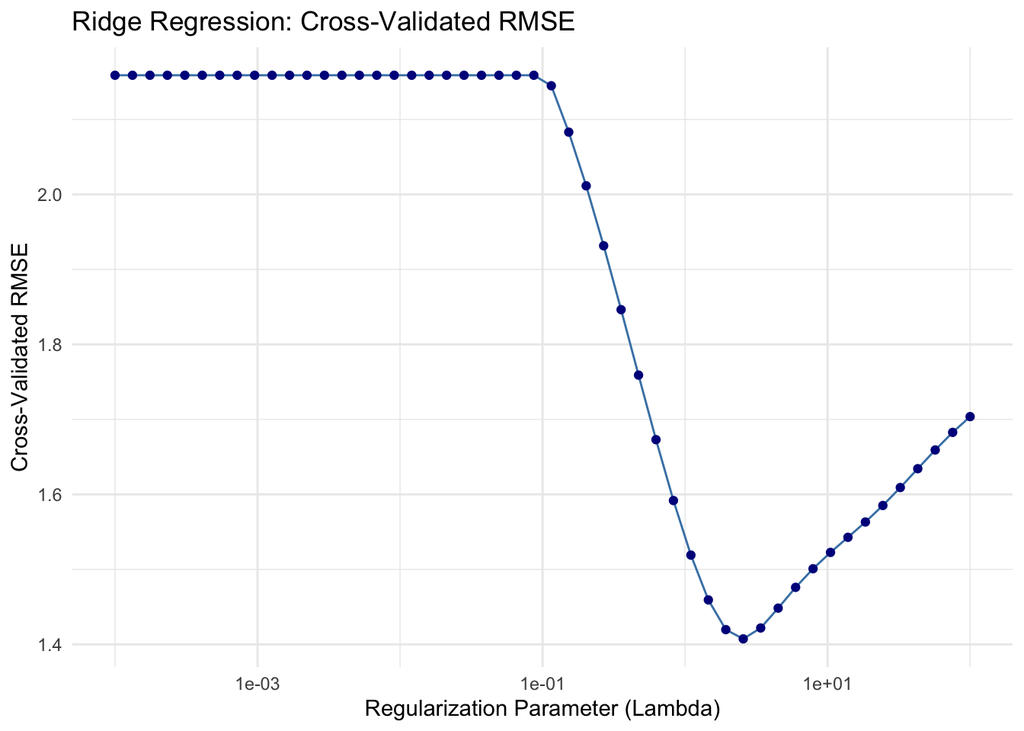

```r
# Visualize
ggplot(ridge_model$results, aes(x = lambda, y = RMSE)) +
  geom_line(color = "steelblue") +
  geom_point(color = "darkblue", size = 1.5) +
  scale_x_log10() +
  labs(
    title = "Ridge Regression: Cross-Validated RMSE",
    x = "Regularization Parameter (Lambda)",
    y = "Cross-Validated RMSE"
  ) +
  theme_minimal()
```

```r
# Predict test observations
ridge_predictions <- predict(
  ridge_model,
  newdata = x_test
)

# Test-set performance
ridge_test_results <- postResample(
  pred = ridge_predictions,
  obs = y_test
)

ridge_test_results
```

```
     RMSE  Rsquared       MAE
1.2210206 0.6871973 0.9159219
```

```r
# Verify imputation
cat("Missing values before imputation:",
    sum(is.na(x_train)), "\n")
```

```
Missing values before imputation: 75
```

```r
cat("Missing values after imputation:",
    sum(is.na(x_train_processed)), "\n")
```

```
Missing values after imputation: 0
```

```r
cat("Missing values in processed test data:",
    sum(is.na(x_test_processed)), "\n")
```

```
Missing values in processed test data: 0
```

### Interpretation: Ridge Regression Model

The Chemical Manufacturing Process data set contains 176 observations and 57 predictor variables. The response variable is manufacturing yield, expressed as a percentage.

The data set was divided into training and testing sets, and missing predictor values were handled using median imputation. Near-zero-variance filtering, centering, and scaling were applied during model preprocessing.

Ridge Regression was selected to predict manufacturing yield. Repeated 10-fold cross-validation was used to tune the regularization parameter, lambda, with RMSE as the performance metric.

The model achieved a cross-validated RMSE of approximately 1.4073. This indicates that the model’s prediction errors have a root mean squared magnitude of approximately 1.41 percentage points during cross-validation.

**d. Predict the response for the test set. What is the value of the performance metric and how does this compare with the resampled performance metric on the training set?**

```r
# Predict response for the test set
ridge_predictions <- predict(
  ridge_model,
  newdata = x_test
)

# Calculate test performance
ridge_test_results <- postResample(
  pred = ridge_predictions,
  obs = y_test
)

ridge_test_results
```

```
     RMSE  Rsquared       MAE
1.2210206 0.6871973 0.9159219
```

```r
# Compare training CV and test RMSE
performance_comparison <- tibble(
  Dataset = c("Cross-validation", "Test"),
  RMSE = c(
    min(ridge_model$results$RMSE),
    unname(ridge_test_results["RMSE"])
  )
)

performance_comparison
```

```
# A tibble: 2 × 2
  Dataset           RMSE
  <chr>            <dbl>
1 Cross-validation  1.41
2 Test              1.22
```

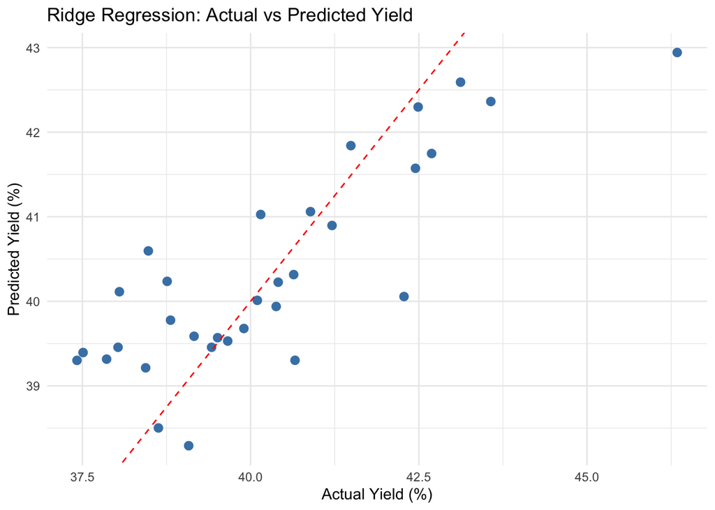

```r
# Create prediction data
ridge_test_df <- tibble(
  Actual = y_test,
  Predicted = as.numeric(ridge_predictions)
)

# Plot
ggplot(ridge_test_df, aes(x = Actual, y = Predicted)) +
  geom_point(color = "steelblue", size = 2.5) +
  geom_abline(
    slope = 1,
    intercept = 0,
    linetype = "dashed",
    color = "red"
  ) +
  labs(
    title = "Ridge Regression: Actual vs Predicted Yield",
    x = "Actual Yield (%)",
    y = "Predicted Yield (%)"
  ) +
  theme_minimal()
```

### Interpretation: Test-Set Performance

The Ridge Regression model was evaluated on the testing data set to determine its predictive performance on unseen observations.

The model achieved a test RMSE of approximately 1.2210, compared with a cross-validated RMSE of 1.4073. The lower test RMSE indicates that the model performed slightly better on the held-out observations than during cross-validation.

The actual-versus-predicted scatterplot shows that several observations are close to the diagonal reference line, indicating reasonably accurate predictions. However, some observations are farther from the line, showing that prediction errors remain.

Overall, the results suggest that Ridge Regression provides useful predictions of manufacturing yield, although additional testing would help establish its reliability on future manufacturing runs.

**e. Which predictors are most important in the model you have trained? Do either the biological or process predictors dominate the list?**

```r
# Variable importance
ridge_importance <- varImp(
  ridge_model,
  scale = TRUE
)

# View importance
ridge_importance
```

```
glmnet variable importance

  only 20 most important variables shown (out of 56)

                       Overall
ManufacturingProcess32  100.00
ManufacturingProcess09   78.89
ManufacturingProcess36   71.51
ManufacturingProcess13   70.38
ManufacturingProcess17   68.26
ManufacturingProcess34   54.48
ManufacturingProcess06   45.70
ManufacturingProcess11   43.90
BiologicalMaterial03     40.71
ManufacturingProcess33   40.21
ManufacturingProcess37   38.63
BiologicalMaterial06     32.69
ManufacturingProcess12   29.01
ManufacturingProcess15   27.54
ManufacturingProcess38   24.00
BiologicalMaterial02     22.66
ManufacturingProcess39   22.62
ManufacturingProcess30   20.77
ManufacturingProcess45   19.78
ManufacturingProcess24   19.66
```

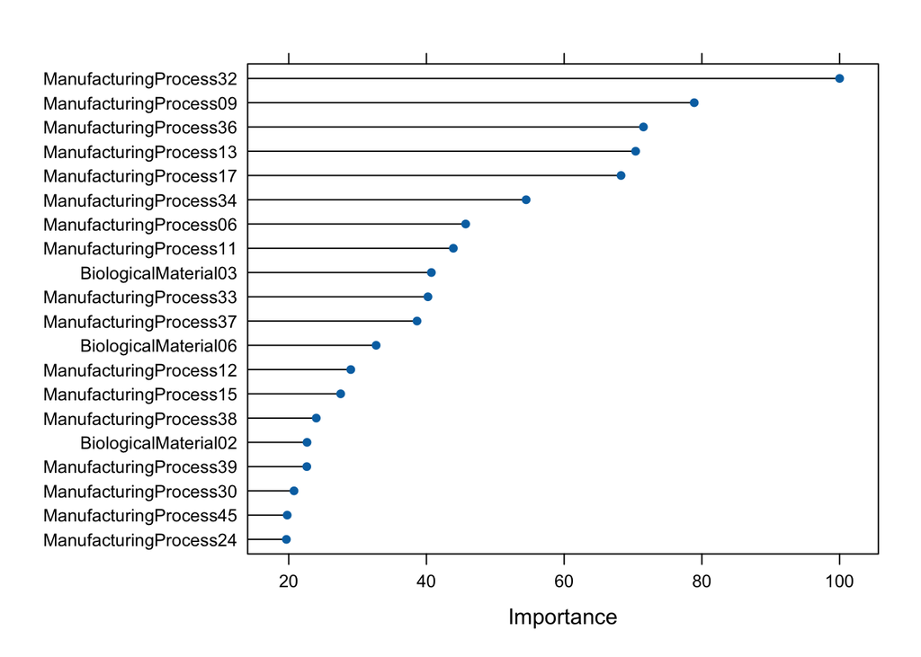

```r
# Plot top 20 predictors
plot(ridge_importance, top = 20)
```

```r
importance_df <- ridge_importance$importance |>
  tibble::rownames_to_column("Predictor") |>
  arrange(desc(Overall))

top_15 <- importance_df |>
  slice_head(n = 15)

top_15
```

```
                Predictor   Overall
1  ManufacturingProcess32 100.00000
2  ManufacturingProcess09  78.88595
3  ManufacturingProcess36  71.51112
4  ManufacturingProcess13  70.37738
5  ManufacturingProcess17  68.25682
6  ManufacturingProcess34  54.47594
7  ManufacturingProcess06  45.69522
8  ManufacturingProcess11  43.90333
9    BiologicalMaterial03  40.71388
10 ManufacturingProcess33  40.21446
11 ManufacturingProcess37  38.62899
12   BiologicalMaterial06  32.69228
13 ManufacturingProcess12  29.01110
14 ManufacturingProcess15  27.54387
15 ManufacturingProcess38  23.99776
```

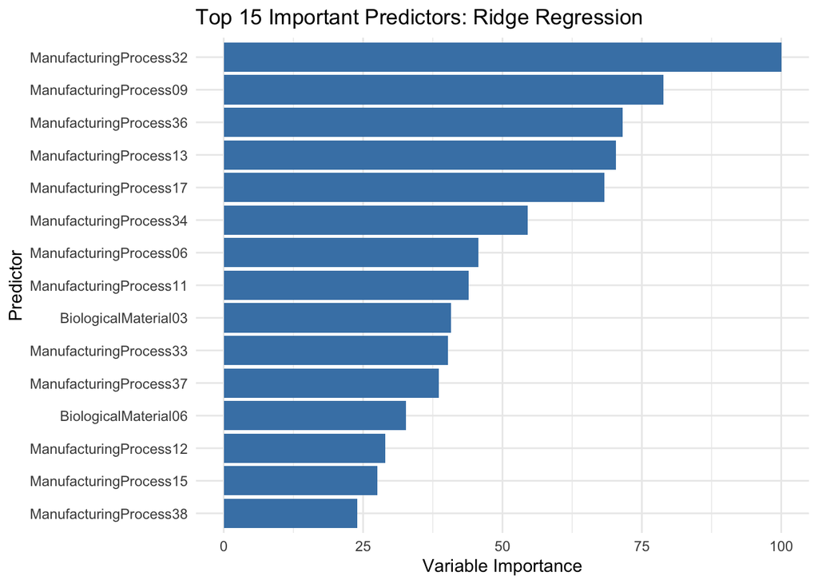

```r
ggplot(top_15,
       aes(x = reorder(Predictor, Overall),
           y = Overall)) +
  geom_col(fill = "steelblue") +
  coord_flip() +
  labs(
    title = "Top 15 Important Predictors: Ridge Regression",
    x = "Predictor",
    y = "Variable Importance"
  ) +
  theme_minimal()
```

```r
names(process_predictors)
```

```
 [1] "BiologicalMaterial01"   "BiologicalMaterial02"   "BiologicalMaterial03"
 [4] "BiologicalMaterial04"   "BiologicalMaterial05"   "BiologicalMaterial06"
 [7] "BiologicalMaterial07"   "BiologicalMaterial08"   "BiologicalMaterial09"
[10] "BiologicalMaterial10"   "BiologicalMaterial11"   "BiologicalMaterial12"
[13] "ManufacturingProcess01" "ManufacturingProcess02" "ManufacturingProcess03"
[16] "ManufacturingProcess04" "ManufacturingProcess05" "ManufacturingProcess06"
[19] "ManufacturingProcess07" "ManufacturingProcess08" "ManufacturingProcess09"
[22] "ManufacturingProcess10" "ManufacturingProcess11" "ManufacturingProcess12"
[25] "ManufacturingProcess13" "ManufacturingProcess14" "ManufacturingProcess15"
[28] "ManufacturingProcess16" "ManufacturingProcess17" "ManufacturingProcess18"
[31] "ManufacturingProcess19" "ManufacturingProcess20" "ManufacturingProcess21"
[34] "ManufacturingProcess22" "ManufacturingProcess23" "ManufacturingProcess24"
[37] "ManufacturingProcess25" "ManufacturingProcess26" "ManufacturingProcess27"
[40] "ManufacturingProcess28" "ManufacturingProcess29" "ManufacturingProcess30"
[43] "ManufacturingProcess31" "ManufacturingProcess32" "ManufacturingProcess33"
[46] "ManufacturingProcess34" "ManufacturingProcess35" "ManufacturingProcess36"
[49] "ManufacturingProcess37" "ManufacturingProcess38" "ManufacturingProcess39"
[52] "ManufacturingProcess40" "ManufacturingProcess41" "ManufacturingProcess42"
[55] "ManufacturingProcess43" "ManufacturingProcess44" "ManufacturingProcess45"
```

```r
top_15$Predictor
```

```
 [1] "ManufacturingProcess32" "ManufacturingProcess09" "ManufacturingProcess36"
 [4] "ManufacturingProcess13" "ManufacturingProcess17" "ManufacturingProcess34"
 [7] "ManufacturingProcess06" "ManufacturingProcess11" "BiologicalMaterial03"
[10] "ManufacturingProcess33" "ManufacturingProcess37" "BiologicalMaterial06"
[13] "ManufacturingProcess12" "ManufacturingProcess15" "ManufacturingProcess38"
```

### Interpretation: Important Predictors

The variable importance analysis identified the predictors that contributed most strongly to the Ridge Regression model.

The five most important predictors were ManufacturingProcess32, ManufacturingProcess09, ManufacturingProcess36, ManufacturingProcess13, and ManufacturingProcess17. ManufacturingProcess32 had the highest relative importance.

Among the top 15 predictors, 13 were manufacturing process variables, while only two were biological material variables: BiologicalMaterial03 and BiologicalMaterial06.

These findings indicate that manufacturing process variables dominate the list of important predictors. This suggests that process conditions may play an important role in predicting manufacturing yield. However, the importance rankings do not establish a causal relationship between the predictors and yield.

**f. Explore the relationships between each of the top predictors and the response. How could this information be helpful in improving yield in future runs of the manufacturing process?**

```r
top_5_predictors <- top_15 |>
  slice_head(n = 5) |>
  pull(Predictor)

top_5_predictors
```

```
[1] "ManufacturingProcess32" "ManufacturingProcess09" "ManufacturingProcess36"
[4] "ManufacturingProcess13" "ManufacturingProcess17"
```

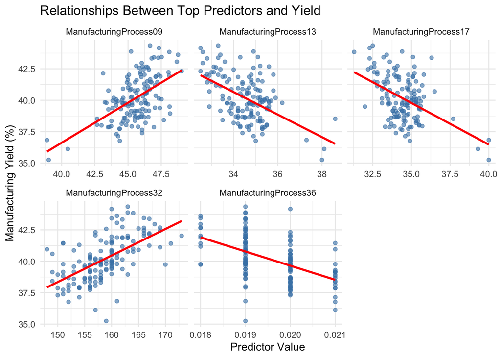

```r
# Prepare the data
relationship_data <- x_train |>
  mutate(Yield = y_train) |>
  select(Yield, all_of(top_5_predictors)) |>
  pivot_longer(
    cols = -Yield,
    names_to = "Predictor",
    values_to = "Value"
  ) |>
  filter(!is.na(Value), !is.na(Yield))
# Plot the relationship
ggplot(
  relationship_data,
  aes(x = Value, y = Yield)
) +
  geom_point(
    color = "steelblue",
    alpha = 0.6
  ) +
  geom_smooth(
    method = "lm",
    se = FALSE,
    color = "red",
    na.rm = TRUE
  ) +
  facet_wrap(
    ~ Predictor,
    scales = "free_x"
  ) +
  labs(
    title = "Relationships Between Top Predictors and Yield",
    x = "Predictor Value",
    y = "Manufacturing Yield (%)"
  ) +
  theme_minimal()
```

### Interpretation: Relationships Between Important Predictors and Manufacturing Yield

The relationships between the five most important predictors and manufacturing yield were examined using scatterplots with fitted linear regression lines.

ManufacturingProcess32 and ManufacturingProcess09 showed positive relationships with yield. This indicates that manufacturing runs with higher values of these predictors generally achieved higher yields.

In contrast, ManufacturingProcess36, ManufacturingProcess13, and ManufacturingProcess17 showed negative relationships with yield. Higher values of these predictors were generally associated with lower manufacturing yields.

These findings suggest that understanding and monitoring important manufacturing process variables may help improve production efficiency. For example, future experiments could investigate whether adjusting process conditions associated with higher yields leads to improved manufacturing performance.

However, these relationships are observational and do not establish causation. Controlled experiments and further analysis would be necessary to determine which process adjustments can reliably increase yield.